# Yeast RNA-seq 48 sample comparison

Keegan Korthauer

# 1 Introduction

This is an analysis of the yeast data with 48 biological replicates in each of two conditions (analyzed in this [publication](https://www.ncbi.nlm.nih.gov/pubmed/26206307/)). We chose this experiment because of the large number of biological replicates, which will allow us to (1) implement null comparisons on random subsets of samples within one condition, (2) compare FDR approaches on their ability to discover ‘true positive’ DE genes using subsets of the full dataset, where ‘true positive’ is defined as a gene detected as DE using all 48 samples in each condition, and (3) start with a null comparison and add in artificial differences to a subset of genes to define ‘true positives’.

Processed count table is made available by the authors in their paper codebase [GitHub repository](https://github.com/bartongroup/profDGE48).

# 2 Set up workspace

```r
# Load packages and source benchmark FDR
library(data.table)
library(tidyr)
library(dplyr)
library(readr)
library(ggplot2)
library(magrittr)
library(R.utils)
library(cowplot)
library(purrr)
library(DESeq2)
library(truncnorm)

# benchmark methods
library(IHW)
library(ashr)
library(qvalue)
library(swfdr)
library(fdrtool)
library(FDRreg)

# comparison tools/functions
library(SummarizedBenchmark)
sourceDirectory("../R/")

# set up parallel backend
library(BiocParallel)
cores <- 4
multicoreParam <- MulticoreParam(workers = cores)
```

# 3 Data download

```r
system("wget https://github.com/bartongroup/profDGE48/raw/master/Preprocessed_data/Snf2_countdata.tar.gz")
system("wget https://github.com/bartongroup/profDGE48/raw/master/Preprocessed_data/WT_countdata.tar.gz")
system("mkdir yeast48-data")
system("tar -xvf WT_countdata.tar.gz -C ./yeast48-data")
system("tar -xvf Snf2_countdata.tar.gz -C ./yeast48-data")
system("rm *.tar.gz")
```

Each of the data files contains two columns, one with a gene/feature name, and one with the count value.

## 3.1 Read data into R and create a count table

Here we make use of the map and map2 functions in the `purrr` package, to swiftly apply the `read_tsv` function from `readr` to read in all of the 96 sample tables, as well as add in the sample name (derived from the file name) to each subtable. Finally, the `reduce` function is used to join all the replicates together.

```r
files <- dir(path = "./yeast48-data/", pattern = "*.bam.gbgout", full.names = TRUE)
sample_names <- sapply(strsplit(dir(path = "./yeast48-data/", pattern = "*.bam.gbgout"), "_MID"),
                       function(x) x[[1]])

counts <- files %>%
  map(read_tsv, col_names = FALSE) %>% # read in all the files individually
  map2(sample_names, ~ dplyr:::rename(.x, !! .y := X2, feature = X1) ) %>% # add sample names
  purrr::reduce(left_join, by = "feature") # reduce with rbind into one dataframe
```

# 4 Analysis of full 48v48 with DESeq2 (non-null)

Now, we’re ready to construct a DESeq2 object. First we pull out the feature names and add them as rownames for the count table, and next we construct a column data object that houses the sample names, replicate numbers, and condition factor (WT versus Snf2 knockout).

## 4.1 Set up DESeq2 object

```r
feats <- (counts %>% select(1))$feature
counts <- as.matrix(counts %>% select(-1))
rownames(counts) <- feats

coldat <- tibble(sample=colnames(counts)) %>%
  separate(sample, sep="_", into=c("condition", "replicate"), remove=FALSE) %>%
  mutate(condition = factor(condition))

# filter low count genes
counts <- counts[rowMeans(counts) > 1,]

dds <- DESeqDataSetFromMatrix(countData = counts,
                              colData = coldat,
                              design= ~ condition)

# results on full set
dds <- DESeq(dds)
```

```
## -- replacing outliers and refitting for 7 genes
## -- DESeq argument 'minReplicatesForReplace' = 7
## -- original counts are preserved in counts(dds)
```

```r
resultsNames(dds) # lists the coefficients
```

```
## [1] "Intercept"            "condition_WT_vs_Snf2"
```

```r
resFULL <- results(dds, name="condition_WT_vs_Snf2")

head(resFULL)
```

```
## log2 fold change (MLE): condition WT vs Snf2
## Wald test p-value: condition WT vs Snf2
## DataFrame with 6 rows and 6 columns
##            baseMean log2FoldChange      lfcSE       stat       pvalue
##           <numeric>      <numeric>  <numeric>  <numeric>    <numeric>
## 15S_rRNA  18.335657    -0.16749327 0.33586795 -0.4986879 6.179993e-01
## 21S_rRNA 107.320791     0.09311348 0.27817113  0.3347345 7.378254e-01
## HRA1       2.526189     0.79300457 0.22278035  3.5595804 3.714477e-04
## ICR1     141.574937    -0.21539845 0.03702317 -5.8179360 5.957870e-09
## LSR1     207.522793     0.13664671 0.15813317  0.8641243 3.875196e-01
## NME1      26.475931    -0.08429524 0.13369572 -0.6305006 5.283671e-01
##                  padj
##             <numeric>
## 15S_rRNA 6.601860e-01
## 21S_rRNA 7.709158e-01
## HRA1     6.412804e-04
## ICR1     1.534397e-08
## LSR1     4.369752e-01
## NME1     5.751167e-01
```

```r
sum(resFULL$padj < 0.05, na.rm=T, independentFiltering = F)
```

```
## [1] 4852
```

## 4.2 Check assumptions

There are many thousand genes detected using the full set. Next, we’ll build input data frame for summarized benchmark.

```r
geneExp <- tbl_df(data.frame(geneName=rownames(resFULL), pval=resFULL$pvalue, SE=resFULL$lfcSE,
                      ind_covariate = resFULL$baseMean, effect_size=resFULL$log2FoldChange,
                      test_statistic=resFULL$stat,
                      pzero=rowSums(counts(dds)==0)/ncol(counts(dds))  ))

# filter NAs and those with less than 50% expressed
geneExp <- geneExp %>% na.omit() %>% dplyr::filter(pzero < 0.5)
```

Check unimodal assumption (for ash).

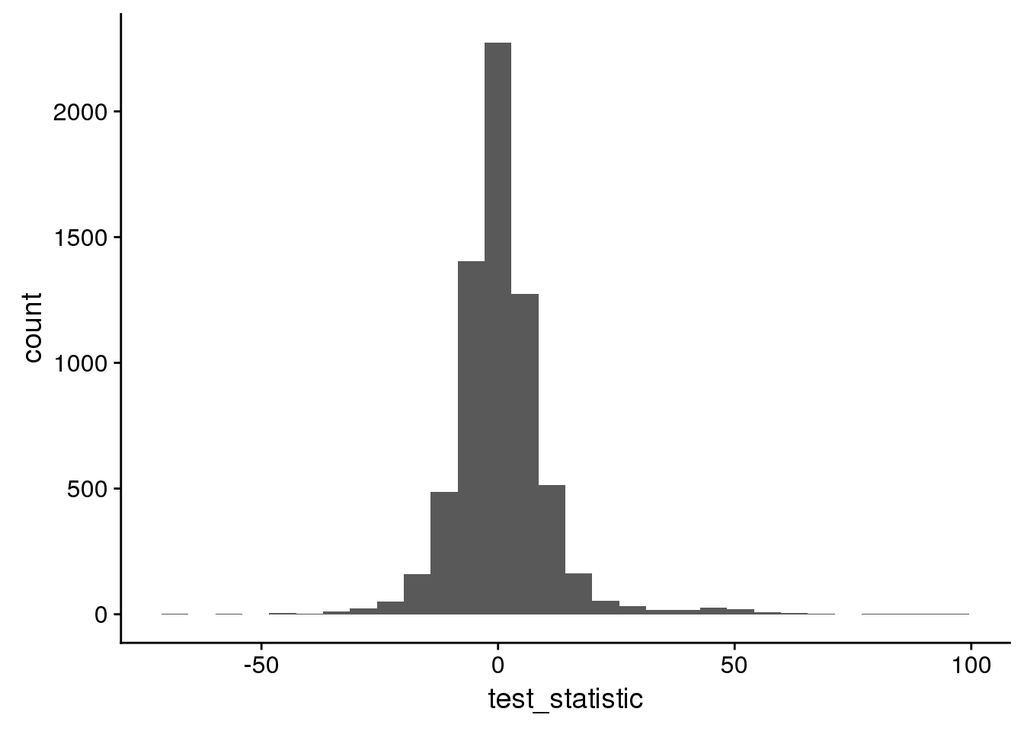

```r
ggplot(data=geneExp, aes(test_statistic)) +
  geom_histogram(bins=30)
```

Look at covariate diagnostic plots.

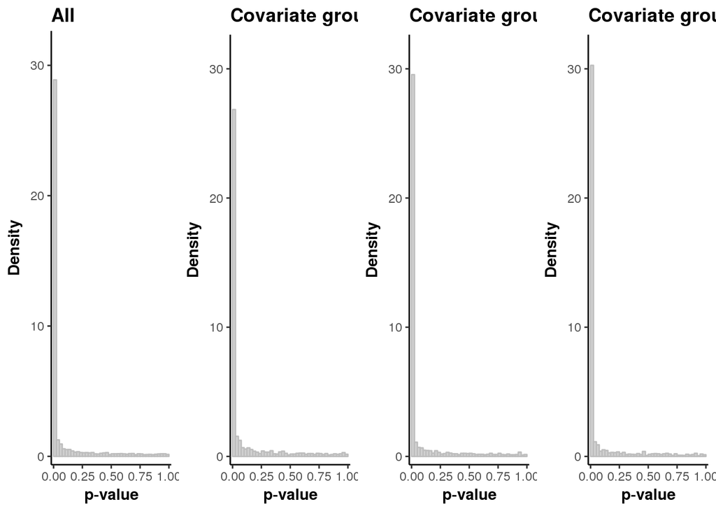

```r
strat_hist(geneExp, pvalue="pval", covariate="ind_covariate", maxy=32)
```

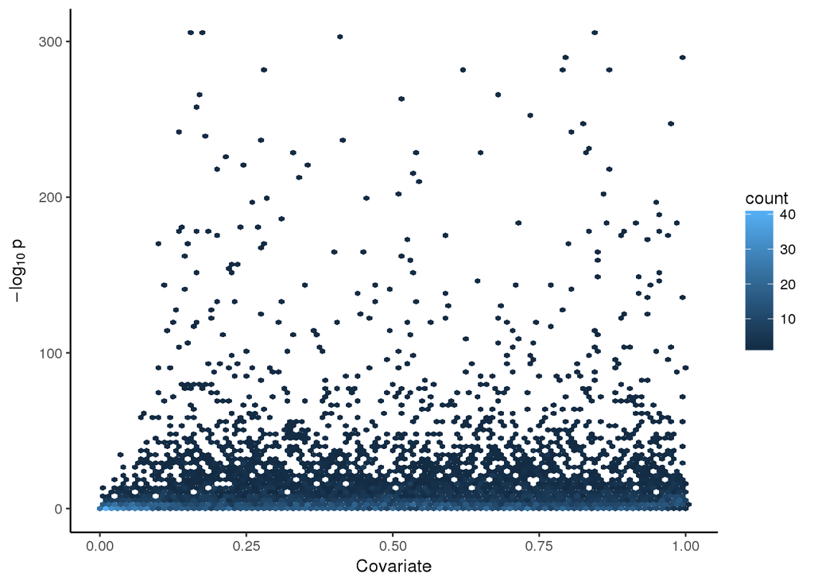

```r
rank_scatter(geneExp, pvalue="pval", covariate="ind_covariate")
```

## 4.3 FDR benchmarking

Run benchmark methods.

```r
bd <- initializeBenchDesign()
sb <- bd %>% buildBench(data=geneExp, parallel = T)
```

```
## <simpleError in seq.default(lb, ub, length = nmids + 1): 'from' must be a finite number>
```

[output not shown]

```r
assayNames(sb) <- "qvalue"
sb <- addDefaultMetrics(sb)
```

Plot results.

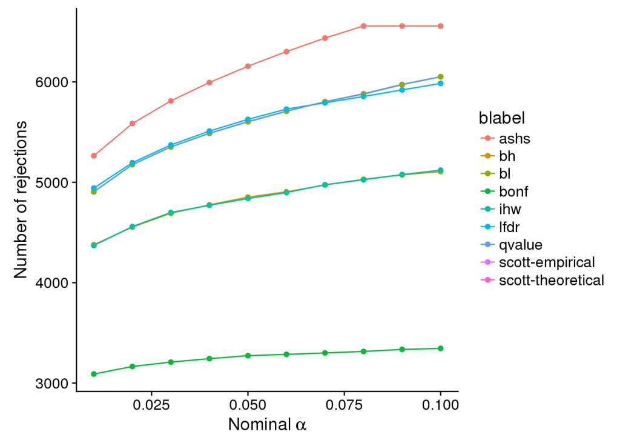

```r
rejections_scatter(sb, supplementary=FALSE)
```

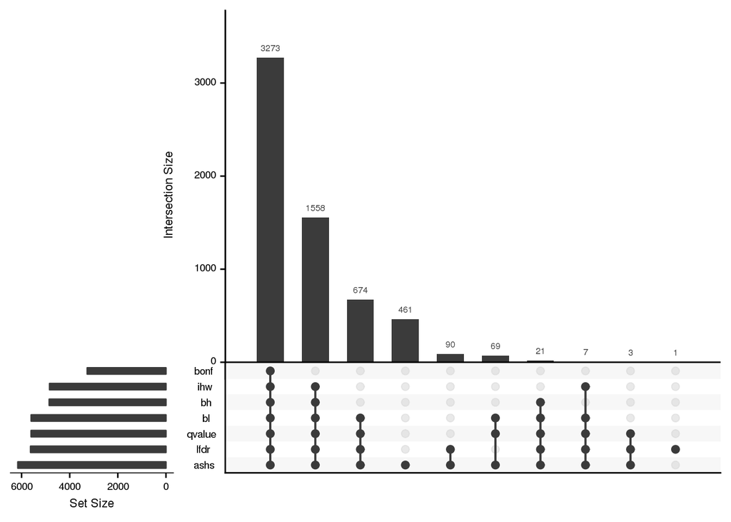

```r
plotFDRMethodsOverlap(sb, alpha=0.05, nsets=ncol(sb), order.by="freq", decreasing=TRUE, supplementary=FALSE)
```

To do: compare this to results using a subset of samples from each condition.

# 5 Null Comparison (10 versus 10)

Here we’ll repeat the above, but for a null comparison 10 versus 10 Snf2 samples, where the groups are selected randomly.

## 5.1 Run DESeq2 on subset

```r
# select a random subset of 20 WT samples
set.seed(8373)
dds_null <- dds[,colData(dds)$condition == "Snf2"]
dds_null <- dds_null[,sample(1:ncol(dds_null), 20)]

# add a fake condition column to coldat
colData(dds_null)$fake <-  factor(c(rep("A", 10), rep("B", 10))[sample(1:20, 20)])
design(dds_null) <- ~fake

# results
dds_null <- DESeq(dds_null)
```

```
## found already estimated dispersions, replacing these
```

```r
resultsNames(dds_null) # lists the coefficients
```

```
## [1] "Intercept"   "fake_B_vs_A"
```

```r
resNULL <- results(dds_null, name="fake_B_vs_A", independentFiltering = F)

head(resNULL)
```

```
## log2 fold change (MLE): fake B vs A
## Wald test p-value: fake B vs A
## DataFrame with 6 rows and 6 columns
##            baseMean log2FoldChange      lfcSE        stat     pvalue
##           <numeric>      <numeric>  <numeric>   <numeric>  <numeric>
## 15S_rRNA  16.938906    1.056379952 0.63014508  1.67640751 0.09365840
## 21S_rRNA 118.528526    0.954284555 0.61376445  1.55480586 0.11999231
## HRA1       1.341537   -0.147130577 0.68225483 -0.21565340 0.82925793
## ICR1     153.750397    0.004694061 0.07172343  0.06544668 0.94781836
## LSR1     200.489926    0.492386527 0.30150605  1.63309005 0.10245006
## NME1      28.790154    0.411403871 0.22854957  1.80006405 0.07185052
##               padj
##          <numeric>
## 15S_rRNA 0.9959654
## 21S_rRNA 0.9959654
## HRA1     0.9959654
## ICR1     0.9959654
## LSR1     0.9959654
## NME1     0.9959654
```

```r
sum(resNULL$padj < 0.05, na.rm=T)
```

```
## [1] 0
```

Build input data frame for summarized benchmark.

```r
geneExp <- tbl_df(data.frame(geneName=rownames(resNULL), pval=resNULL$pvalue, SE=resNULL$lfcSE,
                      ind_covariate = resNULL$baseMean, effect_size=resNULL$log2FoldChange,
                      test_statistic=resNULL$stat,
                      pzero=rowSums(counts(dds)==0)/ncol(counts(dds))  ))

# filter NAs and those with less than 50% expressed
geneExp <- geneExp %>% na.omit() %>% dplyr::filter(pzero < 0.5)
```

## 5.2 Check assumptions

Check unimodal assumption (for ash).

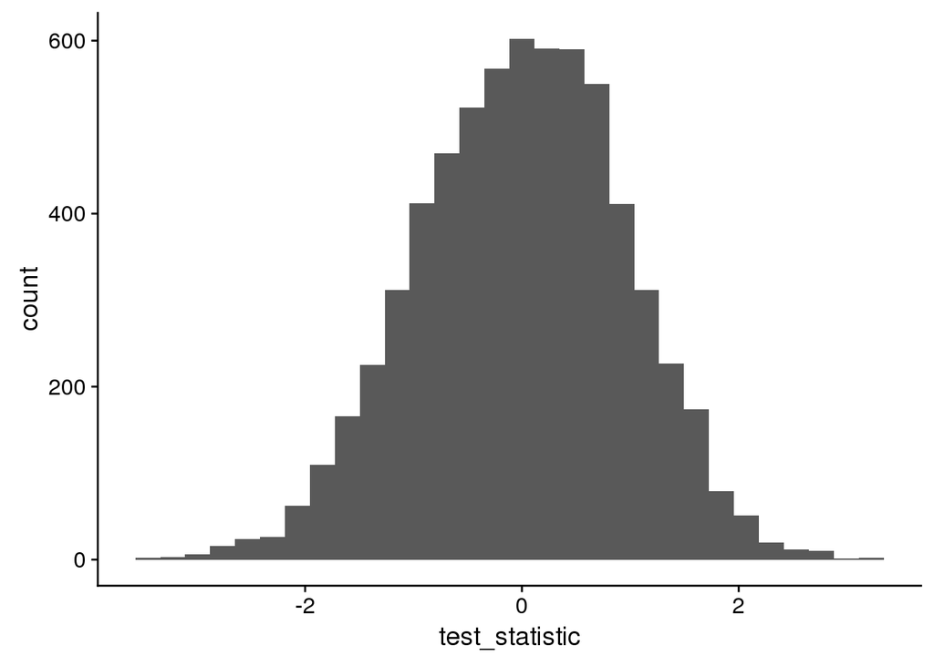

```r
ggplot(data=geneExp, aes(test_statistic)) +
  geom_histogram(bins=30)
```

Look at covariate diagnostic plots.

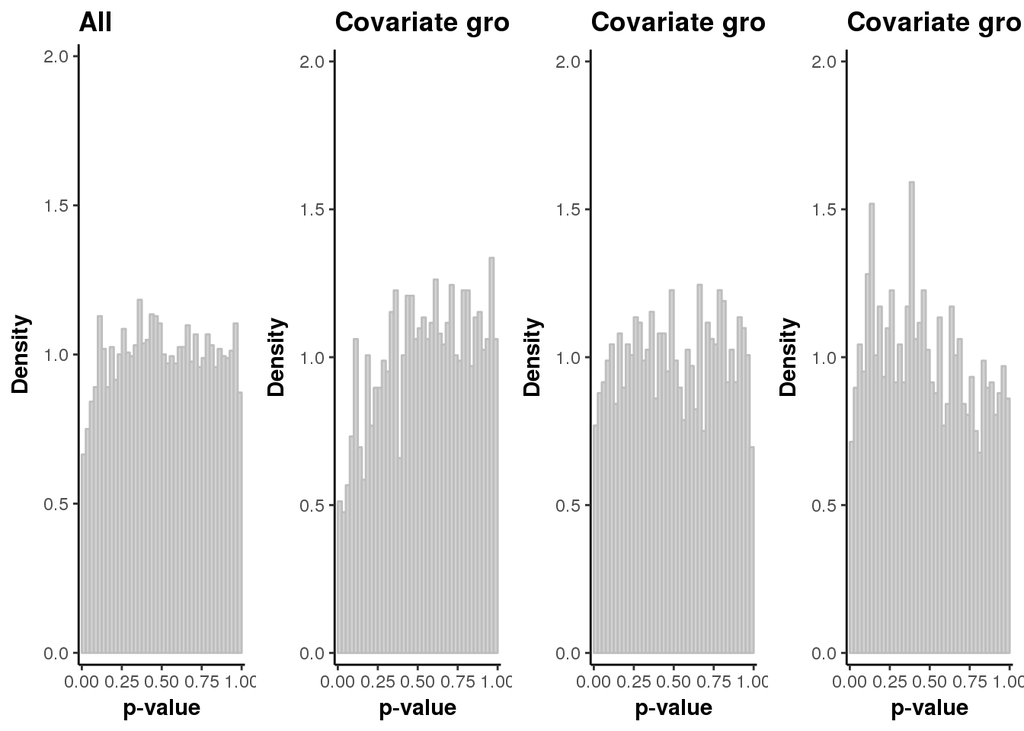

```r
strat_hist(geneExp, pvalue="pval", covariate="ind_covariate", maxy=2)
```

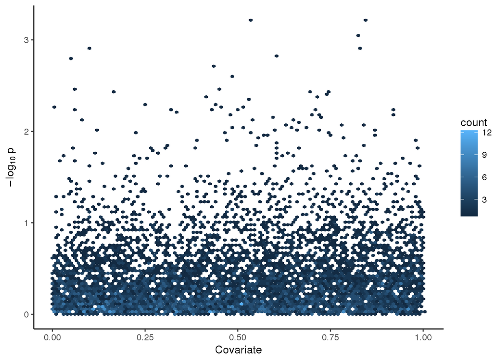

```r
rank_scatter(geneExp, pvalue="pval", covariate="ind_covariate")
```

## 5.3 FDR Benchmark

Run benchmark methods.

```r
bd <- initializeBenchDesign()
sb <- bd %>% buildBench(data=geneExp, parallel = T)

assayNames(sb) <- "qvalue"
sb <- addDefaultMetrics(sb)
```

Plot results.

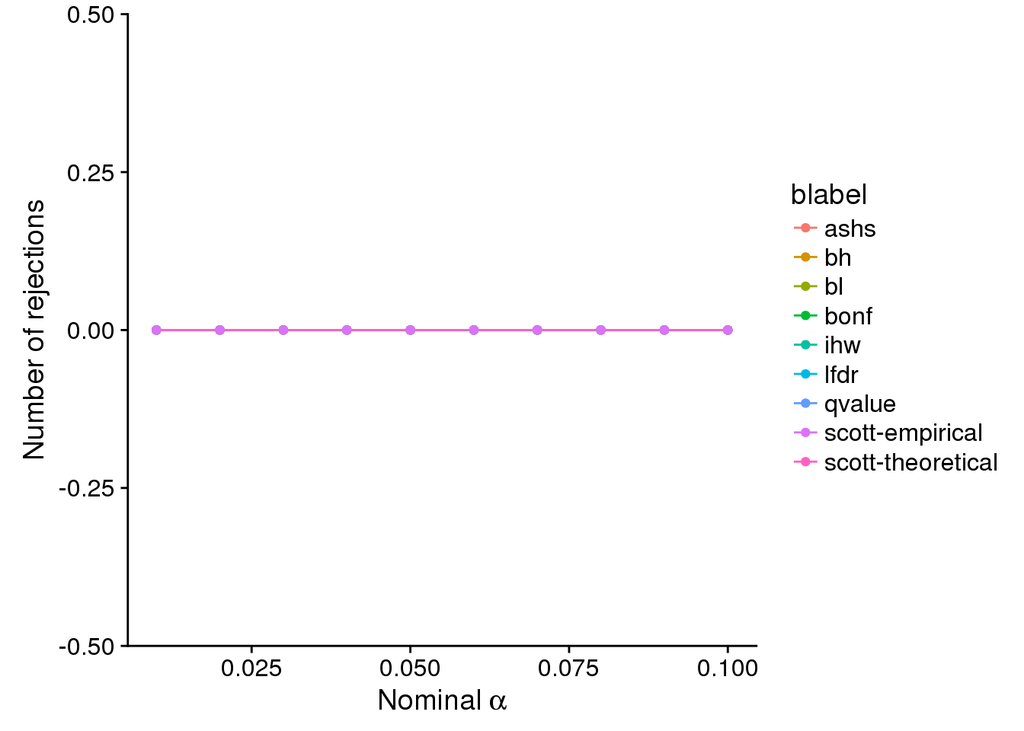

```r
rejections_scatter(sb, supplementary=FALSE)
```

# 6 Non-null Comparison (10 versus 10 null with spike-in)

Here we’ll repeat the above, but adding in some DE genes so that we can evaluate the true positive and false positive rates of each method.

## 6.1 Run DESeq2 on subset

```r
nDE <- 500

# pick random set of nDE genes to add signal to
DE <- sample(1:nrow(dds_null), nDE)
truth <- rep(FALSE, nrow(dds_null))
truth[DE] <- TRUE
names(truth) <- rownames(dds_null)

# randomly sample a log2FC from original FCs (without regard to DE)
log2FC <- rep(0, nrow(dds_null))
log2FC[DE] <- resFULL$log2FoldChange[DE]

counts_new <- counts(dds_null)
counts_new[,colData(dds_null)$fake=="A"] <- counts(dds_null)[,colData(dds_null)$fake=="A"] * 2^log2FC
counts_new <- apply(counts_new, 2, as.integer)
counts(dds_null) <- counts_new

# results
dds_null <- DESeq(dds_null)
```

```
## found already estimated dispersions, replacing these
```

```r
resultsNames(dds_null) # lists the coefficients
```

```
## [1] "Intercept"   "fake_B_vs_A"
```

```r
resNULL <- results(dds_null, name="fake_B_vs_A", independentFiltering = F)

head(resNULL)
```

```
## log2 fold change (MLE): fake B vs A
## Wald test p-value: fake B vs A
## DataFrame with 6 rows and 6 columns
##            baseMean log2FoldChange      lfcSE        stat     pvalue
##           <numeric>      <numeric>  <numeric>   <numeric>  <numeric>
## 15S_rRNA  16.938906    1.056379952 0.63014508  1.67640751 0.09365840
## 21S_rRNA 118.528526    0.954284555 0.61376445  1.55480586 0.11999231
## HRA1       1.341537   -0.146902895 0.68311285 -0.21504924 0.82972893
## ICR1     153.750397    0.004690101 0.07175327  0.06536428 0.94788396
## LSR1     200.489926    0.492386527 0.30150605  1.63309005 0.10245006
## NME1      28.790154    0.411382441 0.22872231  1.79861092 0.07208025
##               padj
##          <numeric>
## 15S_rRNA 0.7930014
## 21S_rRNA 0.8105032
## HRA1     0.9857823
## ICR1     0.9950041
## LSR1     0.8001736
## NME1     0.7204728
```

```r
sum(resNULL$padj < 0.05, na.rm=T)
```

```
## [1] 243
```

Build input data frame for summarized benchmark.

```r
geneExp <- tbl_df(data.frame(geneName=rownames(resNULL), pval=resNULL$pvalue, SE=resNULL$lfcSE,
                      ind_covariate = resNULL$baseMean, effect_size=resNULL$log2FoldChange,
                      test_statistic=resNULL$stat,
                      qvalue=truth,
                      pzero=rowSums(counts(dds)==0)/ncol(counts(dds))  ))

# filter NAs and those with less than 50% expressed
geneExp <- geneExp %>% na.omit() %>% dplyr::filter(pzero < 0.5)
```

## 6.2 Check assumptions

Check unimodal assumption (for ash).

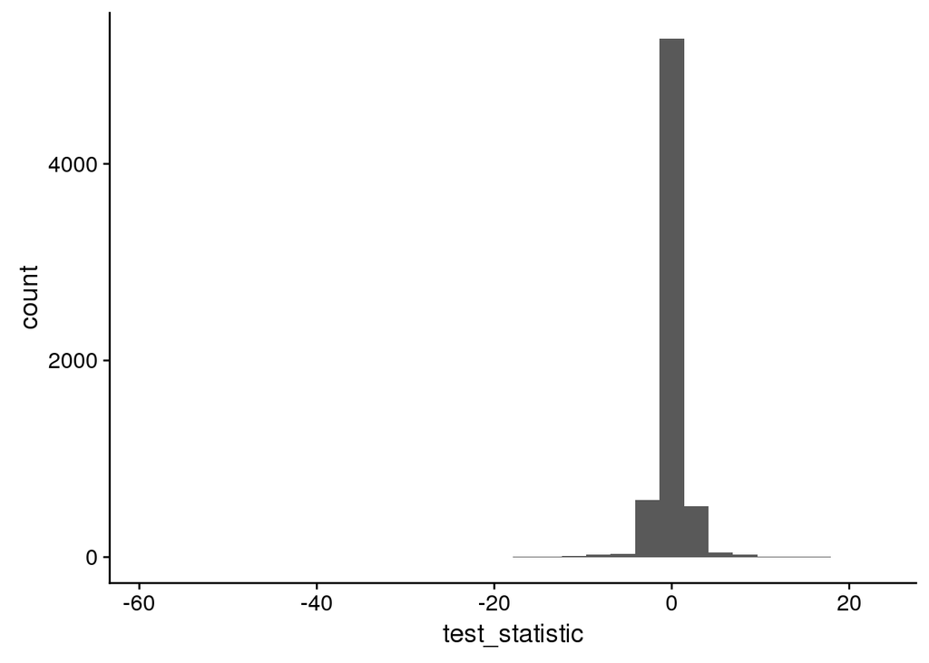

```r
ggplot(data=geneExp, aes(test_statistic)) +
  geom_histogram(bins=30)
```

Look at covariate diagnostic plots.

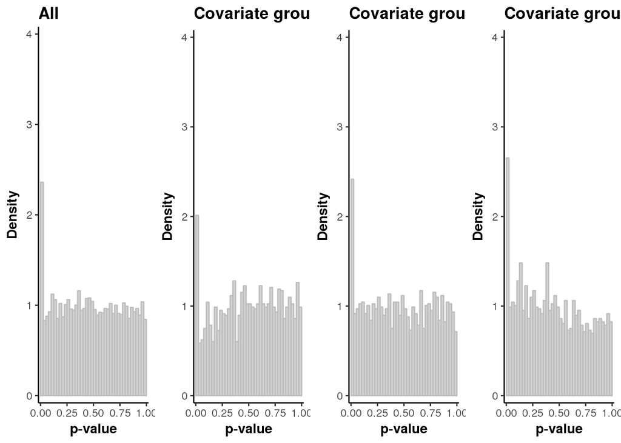

```r
strat_hist(geneExp, pvalue="pval", covariate="ind_covariate", maxy=4)
```

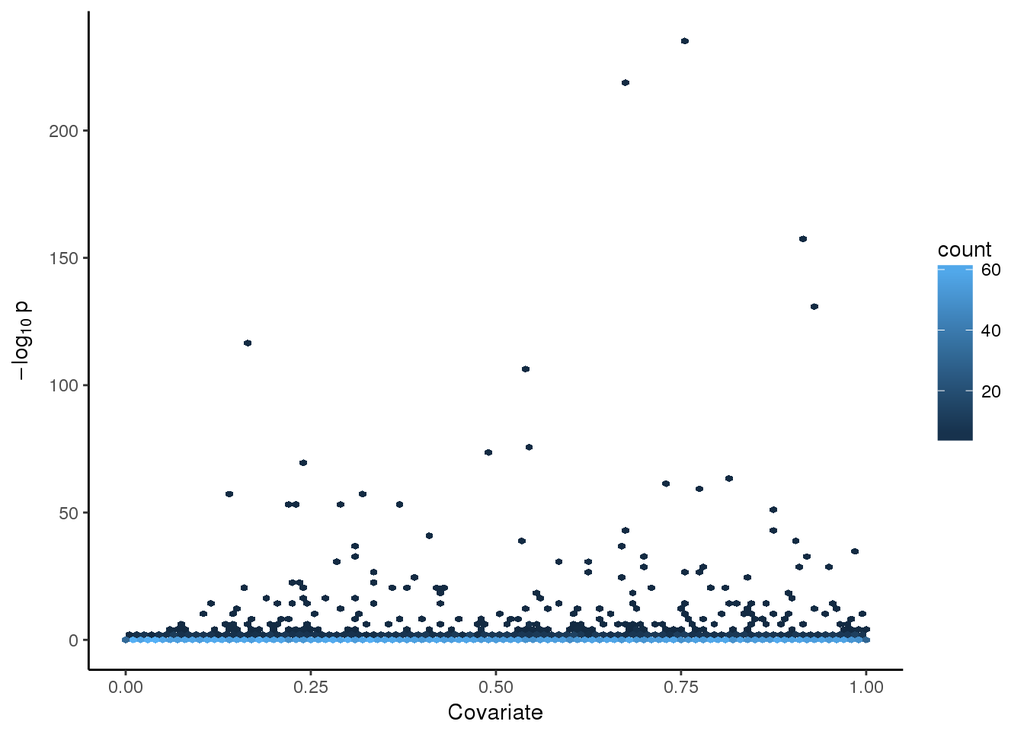

```r
rank_scatter(geneExp, pvalue="pval", covariate="ind_covariate")
```

## 6.3 FDR benchmark

Run benchmark methods and examine ROC curve.

```r
bd <- initializeBenchDesign()
sb <- bd %>% buildBench(data=geneExp, parallel = T, truthCols = "qvalue")
```

```
## <simpleError in seq.default(lb, ub, length = nmids + 1): 'from' must be a finite number>
```

[output not shown]

[output cut: 210 more lines]

[output not shown]

```r
sb <- addDefaultMetrics(sb)
pf <- estimatePerformanceMetrics(sb, alpha = c(0.001, 0.01, 0.025, 0.05, 0.1, 0.2), tidy=TRUE)
tpr <- pf %>% filter(performanceMetric == "TPR") %>%
  mutate(TPR=value) %>%
  select(blabel, alpha, TPR)
fpr <- pf %>% filter(performanceMetric == "FPR") %>%
  mutate(FPR=value) %>%
  select(blabel, alpha, FPR)
roc <- left_join(tpr, fpr) %>%
  filter(blabel %in% c("ashs", "lfdr", "ihw-a10", "bl-df03", "qvalue", "bh", "bonf",
             "scott-empirical", "scott-theoretical"))
```

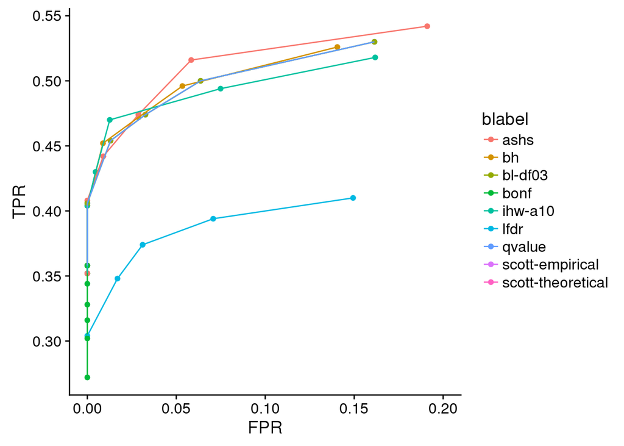

```r
# fpr vs tpr
ggplot(data=roc,aes(FPR, TPR, color=blabel)) +
  geom_point() +
  geom_line() +
  xlim(0,0.2)
```

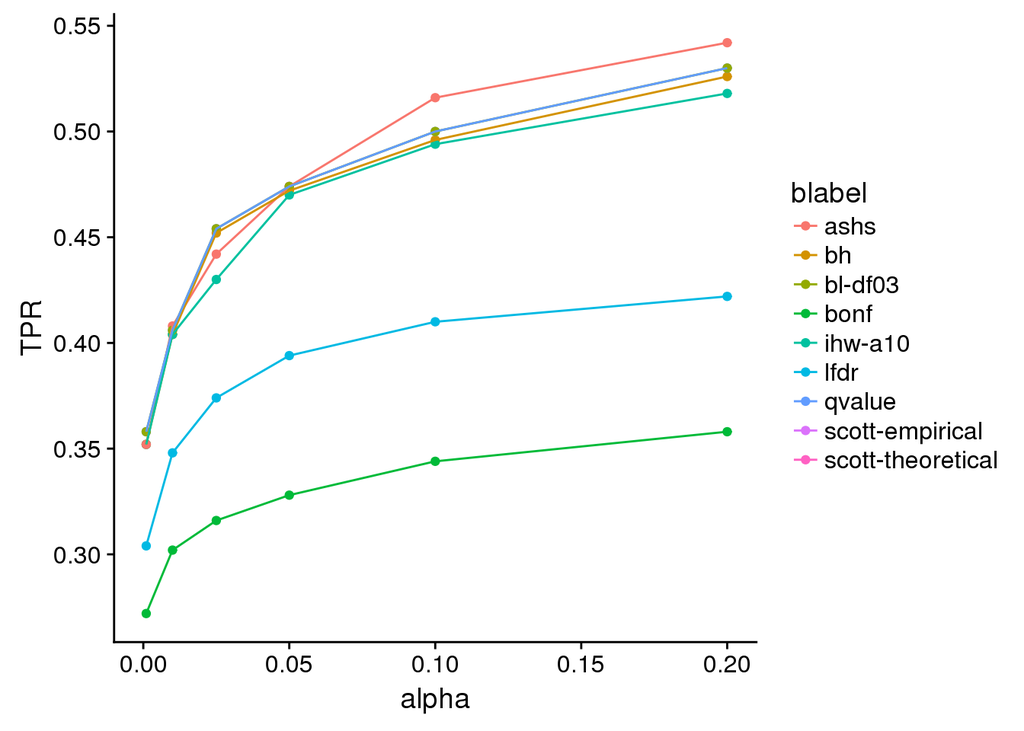

```r
# alpha vs tpr
ggplot(data=roc,aes(alpha, TPR, color=blabel)) +
  geom_point() +
  geom_line() +
  xlim(0,0.2)
```

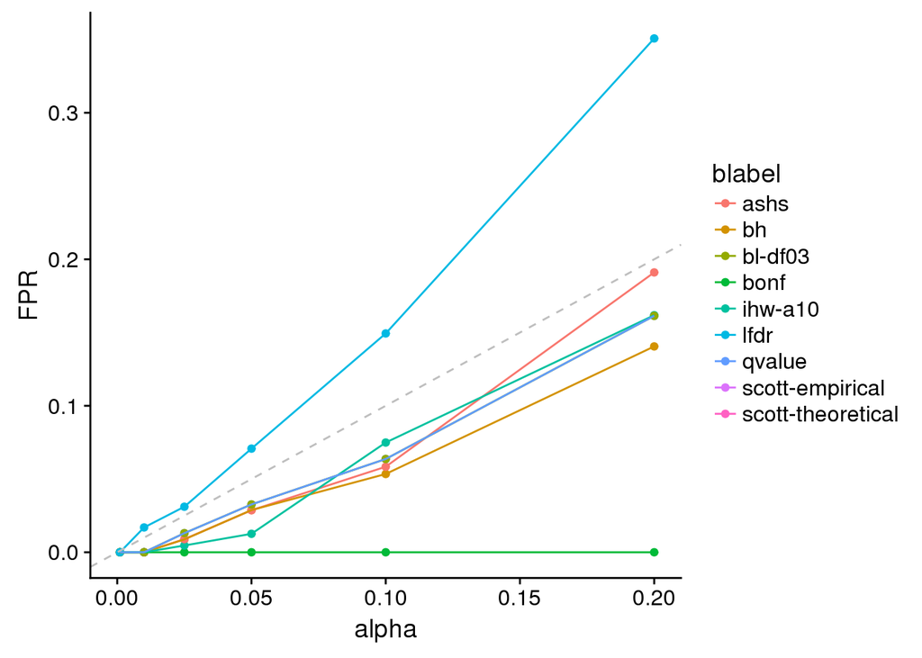

```r
# alpha vs fpr
ggplot(data=roc,aes(alpha, FPR, color=blabel)) +
  geom_point() +
  geom_line() +
  xlim(0,0.2)+
  geom_abline(slope=1, linetype="dashed", color="grey")
```

Plot results.

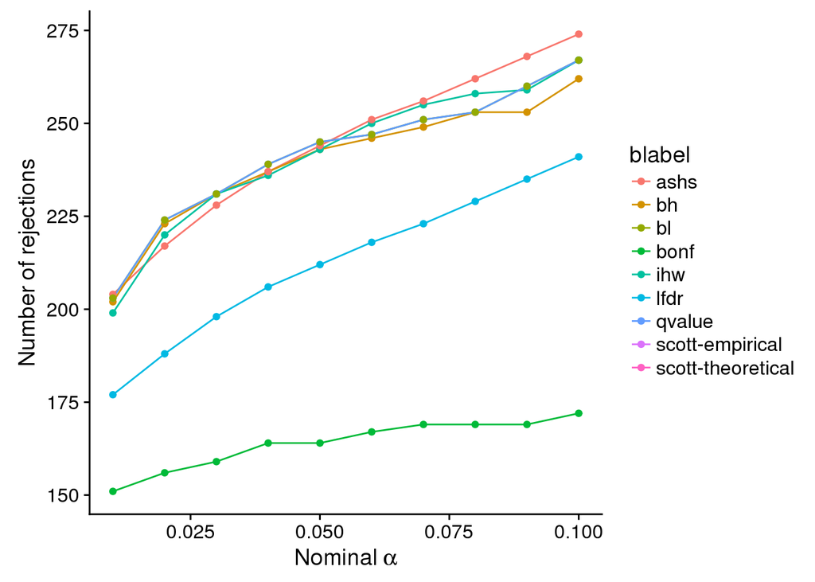

```r
rejections_scatter(sb, supplementary=FALSE)
```

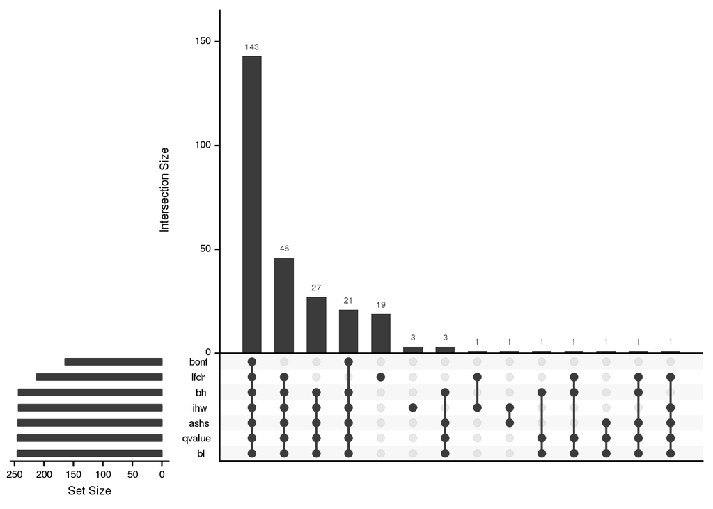

```r
plotFDRMethodsOverlap(sb, alpha=0.05, nsets=ncol(sb), order.by="freq", decreasing=TRUE, supplementary=FALSE)
```

# 7 Null Comparison (5 versus 5)

## 7.1 Run DESeq2 on subset

```r
# select a random subset of 10 WT samples
dds_null <- dds[,colData(dds)$condition == "Snf2"]
dds_null <- dds_null[,sample(1:ncol(dds_null), 10)]

# add a fake condition column to coldat
colData(dds_null)$fake <-  factor(c(rep("A", 5), rep("B", 5))[sample(1:10, 10)])
design(dds_null) <- ~fake

# results
dds_null <- DESeq(dds_null)
```

```
## found already estimated dispersions, replacing these
```

```r
resultsNames(dds_null) # lists the coefficients
```

```
## [1] "Intercept"   "fake_B_vs_A"
```

```r
resNULL <- results(dds_null, name="fake_B_vs_A", independentFiltering = F)

head(resNULL)
```

```
## log2 fold change (MLE): fake B vs A
## Wald test p-value: fake B vs A
## DataFrame with 6 rows and 6 columns
##            baseMean log2FoldChange     lfcSE       stat    pvalue
##           <numeric>      <numeric> <numeric>  <numeric> <numeric>
## 15S_rRNA  43.942651     0.26953207 1.3186936 0.20439325 0.8380462
## 21S_rRNA 197.186364     0.25032838 1.1099790 0.22552533 0.8215706
## HRA1       1.840711     0.12722283 0.8900077 0.14294576 0.8863330
## ICR1     149.885948     0.04441409 0.1294013 0.34322765 0.7314272
## LSR1     285.962247     0.09881412 0.6938030 0.14242389 0.8867452
## NME1      37.585494     0.03543972 0.4823274 0.07347647 0.9414270
##               padj
##          <numeric>
## 15S_rRNA 0.9974908
## 21S_rRNA 0.9974908
## HRA1     0.9974908
## ICR1     0.9974908
## LSR1     0.9974908
## NME1     0.9974908
```

```r
sum(resNULL$padj < 0.05, na.rm=T)
```

```
## [1] 0
```

Build input data frame for summarized benchmark.

```r
geneExp <- tbl_df(data.frame(geneName=rownames(resNULL), pval=resNULL$pvalue, SE=resNULL$lfcSE,
                      ind_covariate = resNULL$baseMean, effect_size=resNULL$log2FoldChange,
                      test_statistic=resNULL$stat,
                      pzero=rowSums(counts(dds)==0)/ncol(counts(dds))  ))

# filter NAs and those with less than 50% expressed
geneExp <- geneExp %>% na.omit() %>% dplyr::filter(pzero < 0.5)
```

## 7.2 Check assumptions

Check unimodal assumption (for ash).

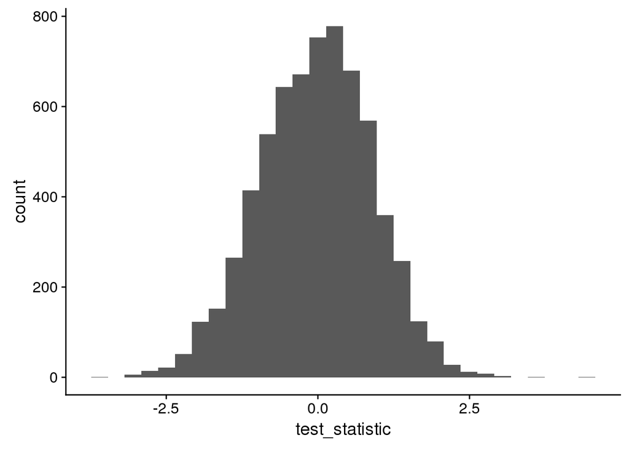

```r
ggplot(data=geneExp, aes(test_statistic)) +
  geom_histogram(bins=30)
```

Look at covariate diagnostic plots.

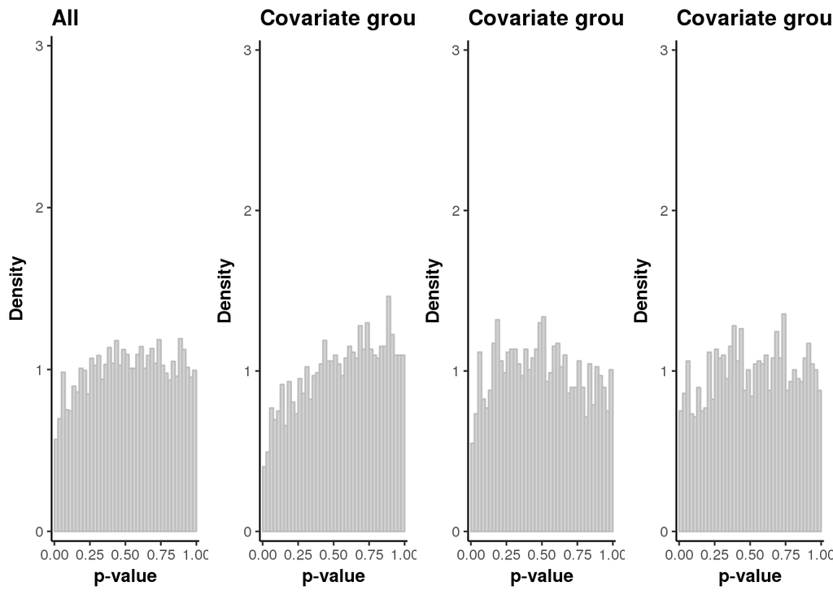

```r
strat_hist(geneExp, pvalue="pval", covariate="ind_covariate", maxy=3)
```

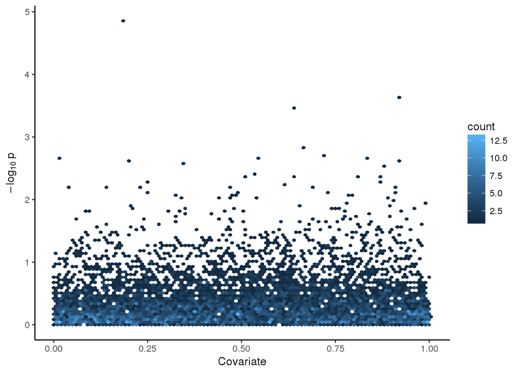

```r
rank_scatter(geneExp, pvalue="pval", covariate="ind_covariate")
```

## 7.3 FDR benchmark

Run benchmark methods.

```r
bd <- initializeBenchDesign()
sb <- bd %>% buildBench(data=geneExp, parallel = T)
```

[output not shown]

[output cut: 167 more lines]

[output not shown]

```r
assayNames(sb) <- "qvalue"
sb <- addDefaultMetrics(sb)
```

Plot results.

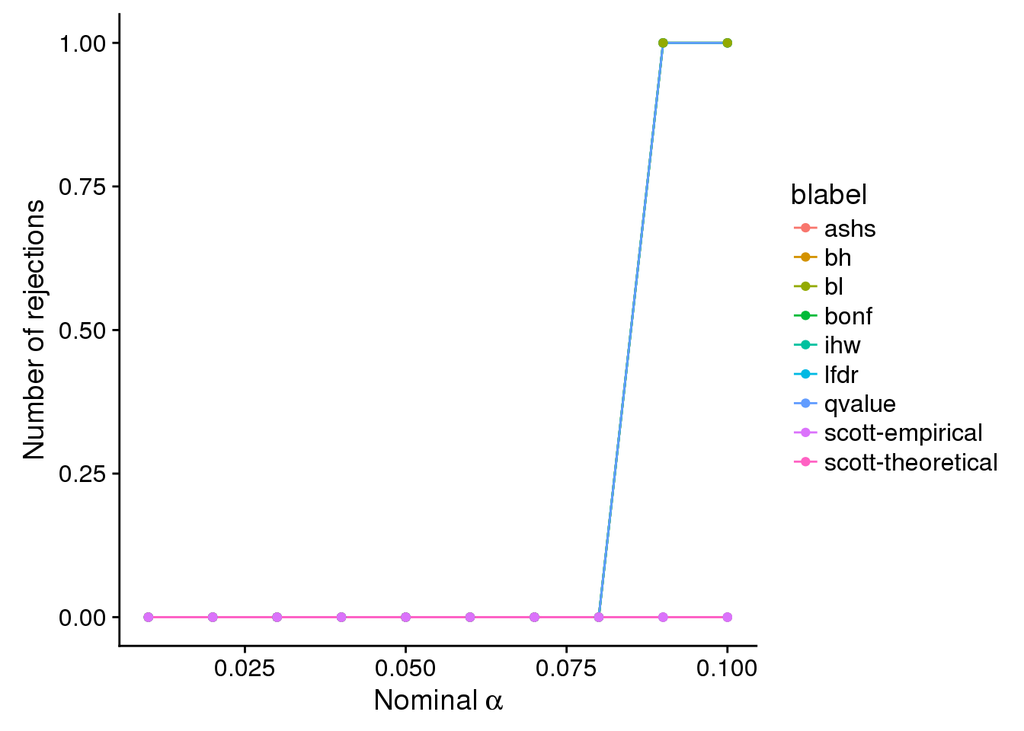

```r
rejections_scatter(sb, supplementary=FALSE)
```

```r
#plotFDRMethodsOverlap(sb, alpha=0.05, nsets=ncol(sb), order.by="freq", decreasing=TRUE, supplementary=FALSE)
```

# 8 Non-null Comparison (5 versus 5 null with spike-in)

Here we’ll repeat the above, but adding in some DE genes so that we can evaluate the true positive and false positive rates of each method.

## 8.1 Run DESeq2 on subset

```r
nDE <- 500

# pick random set of nDE genes to add signal to
DE <- sample(1:nrow(dds_null), nDE)
truth <- rep(FALSE, nrow(dds_null))
truth[DE] <- TRUE
names(truth) <- rownames(dds_null)

# randomly sample a log2FC from original FCs (without regard to DE)
log2FC <- rep(0, nrow(dds_null))
log2FC[DE] <- resFULL$log2FoldChange[DE]

counts_new <- counts(dds_null)
counts_new[,colData(dds_null)$fake=="A"] <- counts(dds_null)[,colData(dds_null)$fake=="A"] * 2^log2FC
counts_new <- apply(counts_new, 2, as.integer)
counts(dds_null) <- counts_new

# results
dds_null <- DESeq(dds_null)
```

```
## found already estimated dispersions, replacing these
```

```r
resultsNames(dds_null) # lists the coefficients
```

```
## [1] "Intercept"   "fake_B_vs_A"
```

```r
resNULL <- results(dds_null, name="fake_B_vs_A", independentFiltering = F)

head(resNULL)
```

```
## log2 fold change (MLE): fake B vs A
## Wald test p-value: fake B vs A
## DataFrame with 6 rows and 6 columns
##            baseMean log2FoldChange     lfcSE       stat    pvalue
##           <numeric>      <numeric> <numeric>  <numeric> <numeric>
## 15S_rRNA  43.942651     0.26953207 1.3186936 0.20439325 0.8380462
## 21S_rRNA 197.186364     0.25032838 1.1099790 0.22552533 0.8215706
## HRA1       1.840711     0.12718092 0.8861343 0.14352330 0.8858769
## ICR1     149.885948     0.04441385 0.1294392 0.34312506 0.7315044
## LSR1     285.962247     0.09881412 0.6938030 0.14242389 0.8867452
## NME1      37.585494     0.03541095 0.4808543 0.07364174 0.9412955
##               padj
##          <numeric>
## 15S_rRNA 0.9937164
## 21S_rRNA 0.9937164
## HRA1     0.9937164
## ICR1     0.9867802
## LSR1     0.9937164
## NME1     0.9948418
```

```r
sum(resNULL$padj < 0.05, na.rm=T)
```

```
## [1] 117
```

Build input data frame for summarized benchmark.

```r
geneExp <- tbl_df(data.frame(geneName=rownames(resNULL), pval=resNULL$pvalue, SE=resNULL$lfcSE,
                      ind_covariate = resNULL$baseMean, effect_size=resNULL$log2FoldChange,
                      test_statistic=resNULL$stat,
                      qvalue=truth,
                      pzero=rowSums(counts(dds)==0)/ncol(counts(dds))  ))

# filter NAs and those with less than 50% expressed
geneExp <- geneExp %>% na.omit() %>% dplyr::filter(pzero < 0.5)
```

## 8.2 Check assumptions

Check unimodal assumption (for ash).

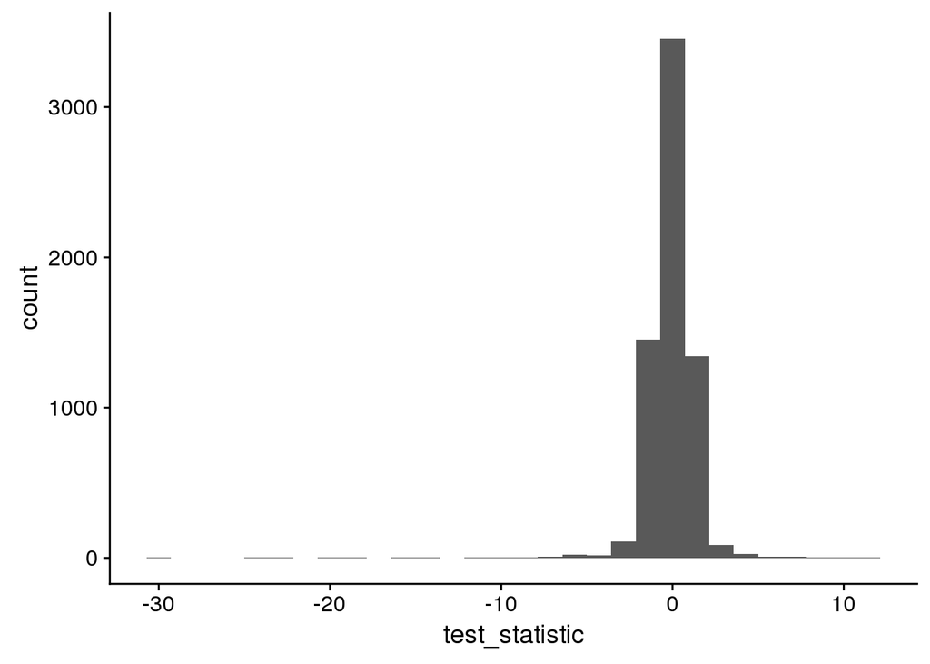

```r
ggplot(data=geneExp, aes(test_statistic)) +
  geom_histogram(bins=30)
```

Look at covariate diagnostic plots.

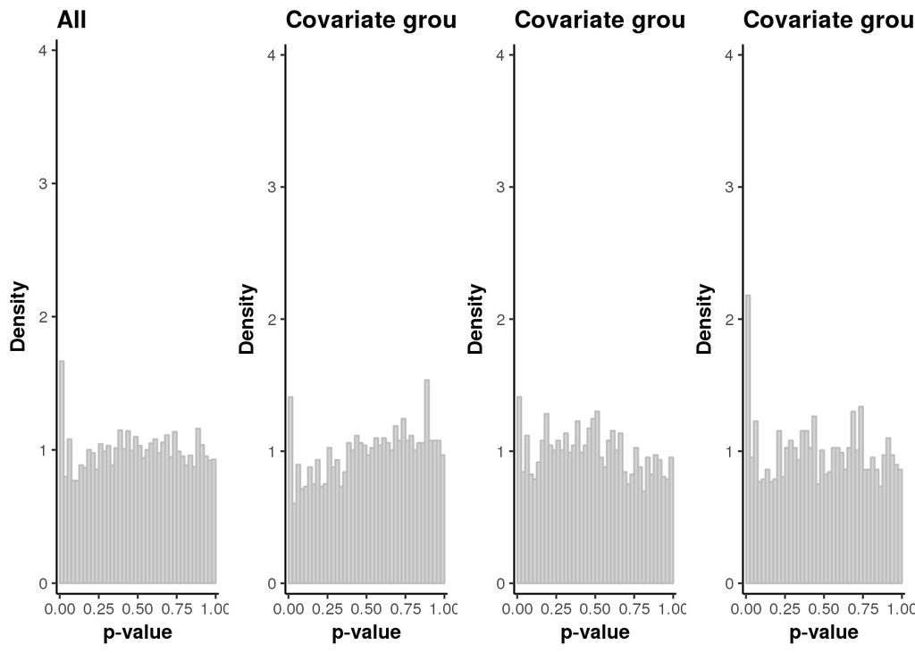

```r
strat_hist(geneExp, pvalue="pval", covariate="ind_covariate", maxy=4)
```

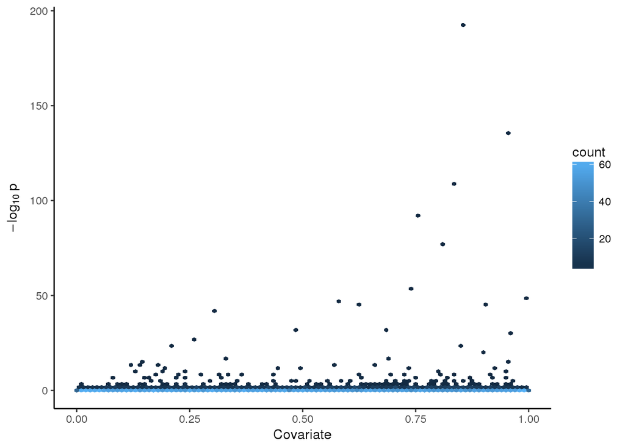

```r
rank_scatter(geneExp, pvalue="pval", covariate="ind_covariate")
```

## 8.3 FDR benchmark

Run benchmark methods and examine ROC curve.

```r
bd <- initializeBenchDesign()
sb <- bd %>% buildBench(data=geneExp, parallel = T, truthCols = "qvalue")
```

[output not shown]

[output cut: 357 more lines]

[output not shown]

```r
sb <- addDefaultMetrics(sb)
pf <- estimatePerformanceMetrics(sb, alpha = c(0.001, 0.01, 0.025, 0.05, 0.1, 0.2), tidy=TRUE)
tpr <- pf %>% filter(performanceMetric == "TPR") %>%
  mutate(TPR=value) %>%
  select(blabel, alpha, TPR)
fpr <- pf %>% filter(performanceMetric == "FPR") %>%
  mutate(FPR=value) %>%
  select(blabel, alpha, FPR)
roc <- left_join(tpr, fpr) %>%
  filter(blabel %in% c("ashs", "lfdr", "ihw-a10", "bl-df03", "qvalue", "bh", "bonf",
             "scott-empirical", "scott-theoretical"))
```

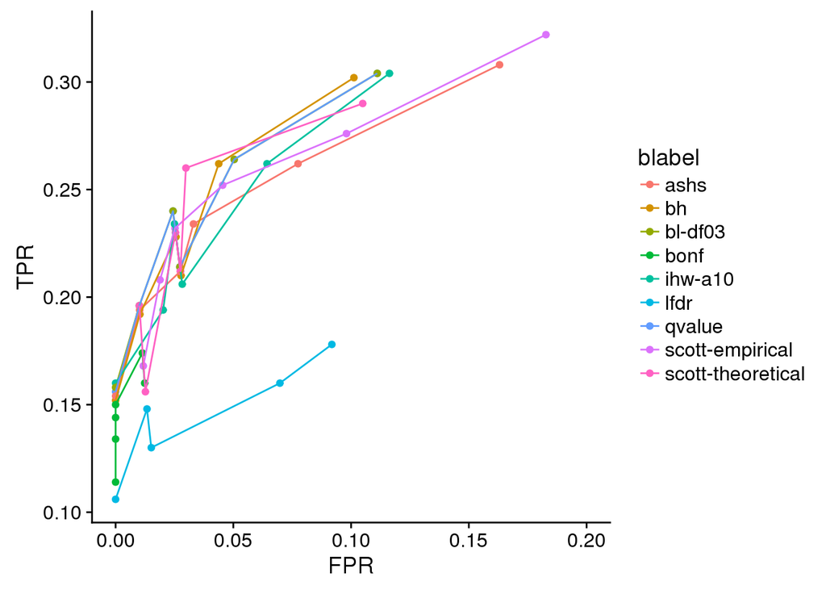

```r
# fpr vs tpr
ggplot(data=roc,aes(FPR, TPR, color=blabel)) +
  geom_point() +
  geom_line() +
  xlim(0,0.2)
```

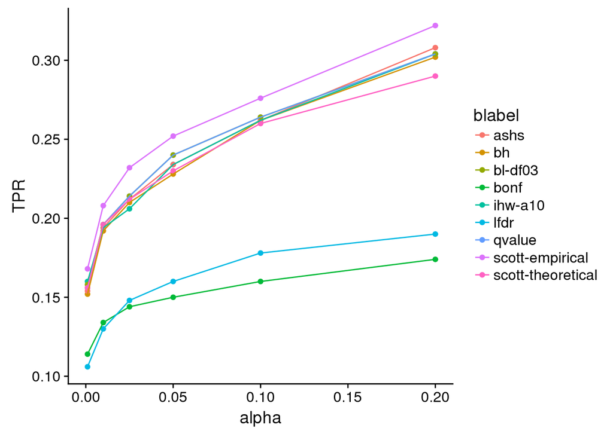

```r
# alpha vs tpr
ggplot(data=roc,aes(alpha, TPR, color=blabel)) +
  geom_point() +
  geom_line() +
  xlim(0,0.2)
```

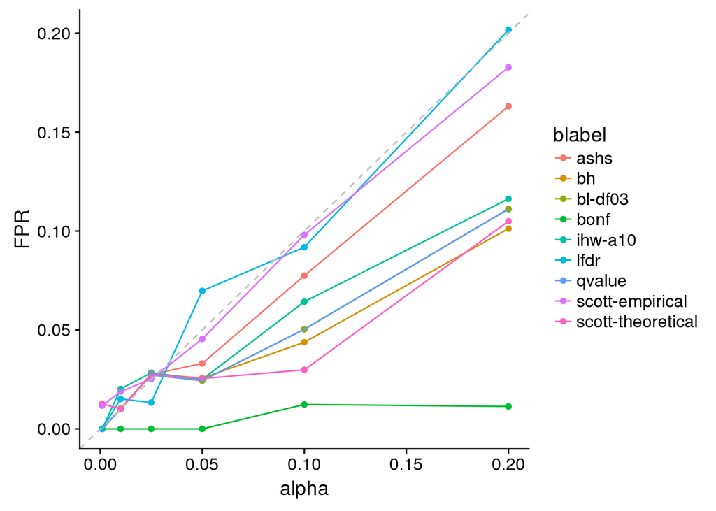

```r
# alpha vs fpr
ggplot(data=roc,aes(alpha, FPR, color=blabel)) +
  geom_point() +
  geom_line() +
  xlim(0,0.2) +
  geom_abline(slope=1, linetype="dashed", color="grey")
```

Plot results.

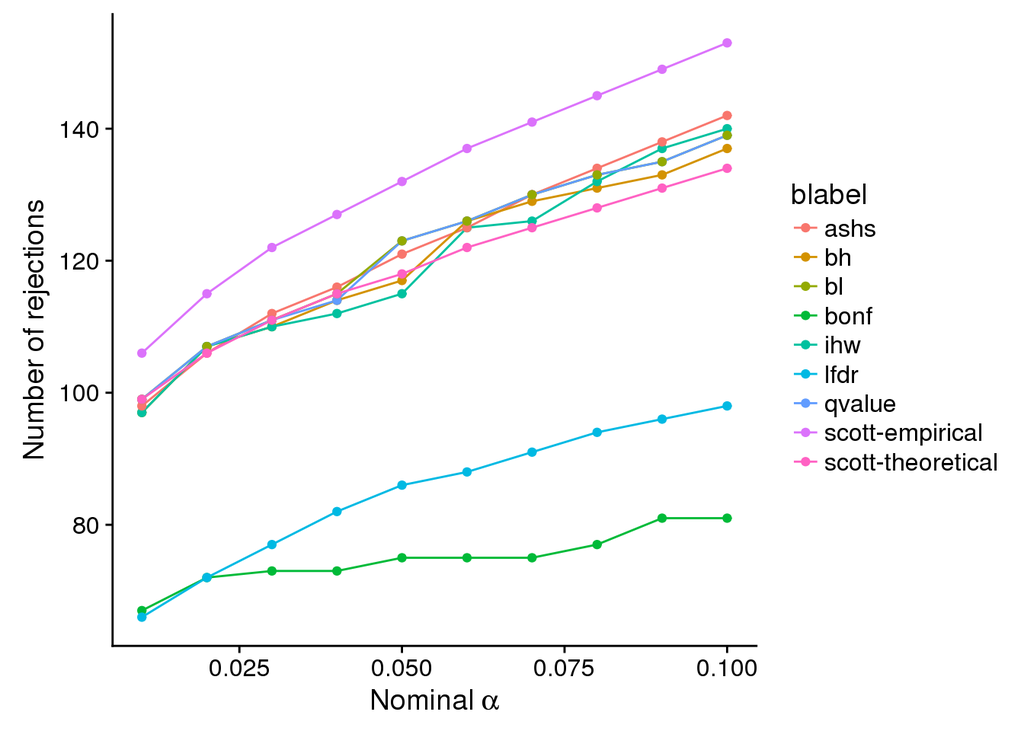

```r
rejections_scatter(sb, supplementary=FALSE)
```

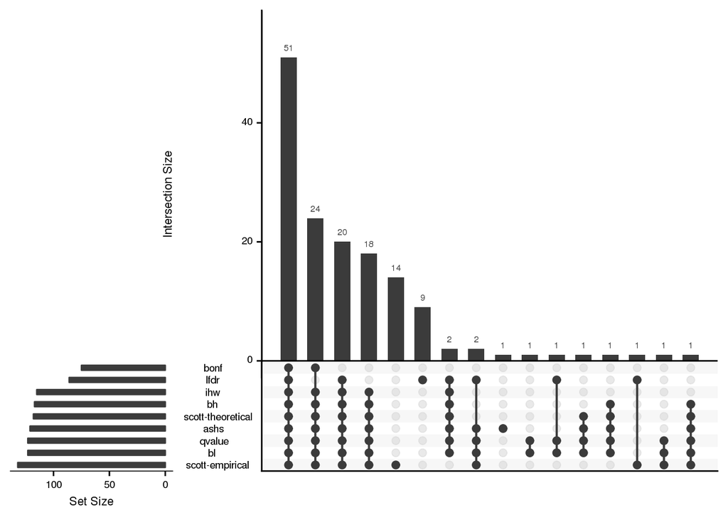

```r
plotFDRMethodsOverlap(sb, alpha=0.05, nsets=ncol(sb), order.by="freq", decreasing=TRUE, supplementary=FALSE)
```